# Week 4 Starter Notes

Download .qmd

**Warning**

Download the data that we will be using this week at the followings links and add them to a `data/` directory

IMDb data

Rainfall data

Eras Tour data

## Data Joins

**.Rdata Files**

Once in `R`, data frames can be saves as `.Rdata` files using the syntax:

`save(data_frame1, data_frame2, ..., file = "path/file-name.Rdata")`

and then *loaded* into `R` using the syntax:

`load("path/file-name.Rdata")`

This can be preferable when saving intermediate datasets in an analysis because `.Rdata` files are much smaller and more memory efficient than `.csv` files. Additionally, you can save and load multiple data frames at once!

You can see that this is useful here, where we have 7 related data frames saved in `imdb_data.Rdata`, which are then loaded in one line below.

We will use 7 datasets that describe movies from [IMDb](https://www.imdb.com/).

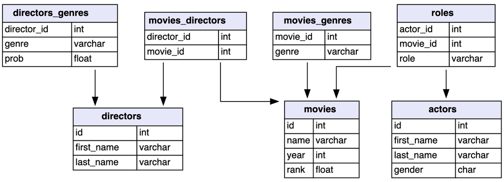

Relationship between data sets in IMDb movie data.

```r
load(file = "data/imdb_data.Rdata")
```

On Wednesday will also look at joining datasets created from the Lab 2 Rodent data. **Note that you will need to change the file path to be appropriate for your directory strucure!**

```r
rodent <- read_csv("../../lab_assignments/lab2/surveys.csv")
species <- rodent |>
  select(genus:taxa, species_id) |>
  distinct()

measurements <- rodent |>
  select(genus, species, sex:weight) |>
  rename(genus_name = genus)
```

## Data Pivots

Example data includes the `cereal` dataset from the `liver` package (which we saw last week)…

```r
library(liver)
data(cereal)
```

… and daily rainfall observed in SLO in January 2023. Data source

```r
slo_rainfall <- read_excel("data/2023-rainfall-slo.xlsx")

slo_rainfall <- slo_rainfall |>
  mutate(across(Sunday:Saturday, as.numeric))
```

## Factors with `forcats`

To practice working with factor variables, we will use data on songs that Taylor Swift included in the Era’s Tour.

```r
full_eras <- read_excel("data/TS_data.xlsx", sheet = "full")
```